# **Classification & Machine Learning**

MATH 3190 coursework • Homework 9

Note that your homework should be completed in Quarto. You can just add your answers and code to this document in the appropriate part. The file should be rendered as an html document or pdf document (html is quicker to render and you will need an installation of LaTeX to render as a pdf). You will “turn in” this homework by uploading the files, the .qmd and output file, to your GitHub `Math_3190_Assignment` repository in the `Homework/Homework_9` directory. Make sure all supporting files (if there are any) are in this directory as well. You should use `git` and `Unix` commands in a terminal for this (i.e. don’t manually upload files to GitHub). In addition, you will submit just your html or pdf file on Canvas to unlock the solutions.

Don’t forget to also put a self-critique comment on Canvas indicating what you did correctly and incorrectly and include any questions you may have about the assignment after submitting the assignment and thoroughly looking through the solutions.

# Problem 1 (70 points)

Before we begin, please re-install the `math3190package` since there was an update to the `classifier_plot()` function that is needed on this assignment. Use either `devtools::install_github("rbrown53/math3190package")` or  
`remotes::install_github("rbrown53/math3190package")`.

The National Institute of Diabetes and Digestive and Kidney Diseases conducted a study on 768 adult female Pima Native Americans living near Phoenix. The purpose of the study was to investigate factors related to diabetes. The response variable in this study (test) was whether or not the patient showed signs of diabetes (1 = yes, 0 = no). One explanatory variable considered was the plasma glucose concentration (in mg/dL) at 2 hours in an oral glucose tolerance test (glucose). Many other potential explanatory variables were considered as well including body mass index (BMI). The goal here is to predict the diabetes status of the subject, which is in the `results` variable.

### Part a (5 points)

Install and/or load the `faraway` package with the `pima` dataset. Set a seed and then split the data into a testing and a training set with the testing set containing 20% of the data values. When you do this, change the name of the variable “test” to “result” since it will be a bit confusing to call that test when we have a test dataset. Then make the `result` variable a factor so **R** treats it as categorical rather than numeric.

```r
library(faraway)
library(tidyverse)
set.seed(39)
data(pima)
pima = mutate(pima, result = test)
pima$test = NULL
pima$result = factor(pima$result)

pima_train = pima[1:614, ]
pima_test = pima[615:768, ]

head(pima_train)
```

```
  pregnant glucose diastolic triceps insulin  bmi diabetes age result
1        6     148        72      35       0 33.6    0.627  50      1
2        1      85        66      29       0 26.6    0.351  31      0
3        8     183        64       0       0 23.3    0.672  32      1
4        1      89        66      23      94 28.1    0.167  21      0
5        0     137        40      35     168 43.1    2.288  33      1
6        5     116        74       0       0 25.6    0.201  30      0
```

```r
head(pima_test)
```

```
    pregnant glucose diastolic triceps insulin  bmi diabetes age result
615       11     138        74      26     144 36.1    0.557  50      1
616        3     106        72       0       0 25.8    0.207  27      0
617        6     117        96       0       0 28.7    0.157  30      0
618        2      68        62      13      15 20.1    0.257  23      0
619        9     112        82      24       0 28.2    1.282  50      1
620        0     119         0       0       0 32.4    0.141  24      1
```

### Part b (6 points)

- Fit a logistic regression model to the training set for predicting `result` from the `glucose` and `bmi` variables.
- Then use the `classifier_plot()` function in the `math3190package` (make sure you re-installed it!) to make a plot that shows the regions on the `glucose`-`bmi`-plane that are predicted to be 0 and 1. This shows how logistic regression divides the classes. Use the **training set** as the `data` input in this function.
- Next, obtain the predictions for the **test set** with a probability cutoff of 0.5 to predict if the person has diabetes. Create a confusion matrix using the `confusionMatrix()` function in the `caret` library. Make sure to put `positive = "1"` for this and all other confusion matrices on this assignment. Print all of the output from that function that shows the confusion matrix and many associated statistics.
- Write a sentence or two discussing how well this model performs in predicting on the test set.

```r
library(math3190package)
library(caret)
model = glm(result ~ glucose + bmi, data = pima_train, family = binomial)
summary(model)
```

```
Call:
glm(formula = result ~ glucose + bmi, family = binomial, data = pima_train)

Coefficients:
             Estimate Std. Error z value Pr(>|z|)
(Intercept) -7.733729   0.685661 -11.279  < 2e-16 ***
glucose      0.033531   0.003586   9.351  < 2e-16 ***
bmi          0.089157   0.015244   5.849 4.96e-09 ***
---
Signif. codes:  0 '***' 0.001 '**' 0.01 '*' 0.05 '.' 0.1 ' ' 1

(Dispersion parameter for binomial family taken to be 1)

    Null deviance: 792.69  on 613  degrees of freedom
Residual deviance: 609.91  on 611  degrees of freedom
AIC: 615.91

Number of Fisher Scoring iterations: 5
```

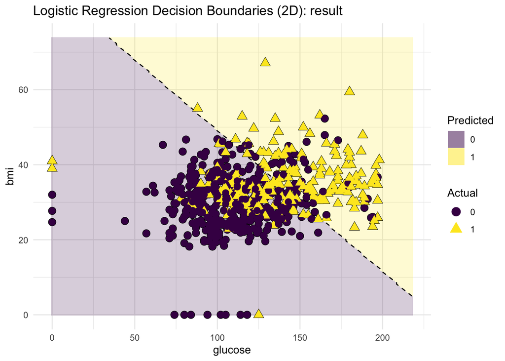

```r
classifier_plot(model, pima_train)
```

```r
probs = predict(model, newdata = pima_test, type = "response")
pred_class = ifelse(probs > 0.5, 1, 0)
pred_class = factor(pred_class, levels = c(0, 1))
actual = factor(pima_test$result, levels = c(0, 1))
confusionMatrix(pred_class, actual, positive = "1")
```

```
Confusion Matrix and Statistics

          Reference
Prediction  0  1
         0 87 29
         1 12 26

               Accuracy : 0.7338
                 95% CI : (0.6566, 0.8017)
    No Information Rate : 0.6429
    P-Value [Acc > NIR] : 0.01041

                  Kappa : 0.3774

 Mcnemar's Test P-Value : 0.01246

            Sensitivity : 0.4727
            Specificity : 0.8788
         Pos Pred Value : 0.6842
         Neg Pred Value : 0.7500
             Prevalence : 0.3571
         Detection Rate : 0.1688
   Detection Prevalence : 0.2468
      Balanced Accuracy : 0.6758

       'Positive' Class : 1
```

```r
# The accuracy of the model is 0.7338, which isn't great, but it's decent considering that the training data wasn't exactly split very well.
# kappa = 0.3774
```

### Part c (3 points)

Now let’s use naïve Bayes to get predictions. Use the `naive_bayes()` function in the `naivebayes` library to fit a model predicting result using `glucose` and `bmi`. Find the predicted probabilities of being a 0 and a 1 for the first observation in the training set.

```r
library(naivebayes)
naive_model = naive_bayes(result ~ glucose + bmi, data = pima_train)
nb_probs = predict(naive_model, newdata = pima_train[1, ], type = "prob")
nb_probs
```

```
             0         1
[1,] 0.4184538 0.5815462
```

```r
# The first observation has 0.4185 probability of being a 0 and a 0.5815 probability of being a 1.
```

### Part d (9 points)

Now find the predicted probability of being a 0 and a 1 for the first observation in the training set “by hand” like we did in the notes on pages 187 and 188. To simplify this a bit, let’s again only use the variables `glucose` and `bmi` here. Of course, use **R** to help you (the `dnorm()` function and some tidyverse functions will be especially nice), but don’t use the `naive_bayes()` function here. Note: these variables we are using to predict are numeric, so we will assume a normal distribution for both of them (maybe not a good assumption, but let’s go with it). After you get the probabilities, compare them to the ones you got in part (c). They should match.

```r
obs1 = pima_train[1, ]
priors = pima_train |>
  count(result) |>
  mutate(prior = n / sum(n))

p0 = priors$prior[priors$result == 0]
p1 = priors$prior[priors$result == 1]

stats = pima_train |>
  group_by(result) |>
  summarize(
    m_glucose = mean(glucose),
    s_glucose = sd(glucose),
    m_bmi = mean(bmi),
    s_bmi = sd(bmi)
  )

lik_g0 = dnorm(obs1$glucose, stats$m_glucose[stats$result == '0'], stats$s_glucose[stats$result == "0"])
lik_b0 = dnorm(obs1$bmi, stats$m_bmi[stats$result == "0"], stats$s_bmi[stats$result == '0'])

lik_g1 = dnorm(obs1$glucose, stats$m_glucose[stats$result == "1"], stats$s_glucose[stats$result == "1"])
lik_b1 = dnorm(obs1$bmi, stats$m_bmi[stats$result == "1"], stats$s_bmi[stats$result == '1'])

num_0 = p0 * lik_g0 * lik_b0
num_1 = p1 * lik_g1 * lik_b1

prob_0 = num_0 / (num_0 + num_1)
prob_1 = num_1 / (num_0 + num_1)

data.frame(prob_0, prob_1)
```

```
     prob_0    prob_1
1 0.4184538 0.5815462
```

```r
# Got 0.4185 for 0 and 0.5815 for 1; they match!
```

### Part e (3 points)

Now fit a naïve Bayes model predicting `result` from `glucose` and `bmi` using a kernel instead of assuming a normal distribution. You can do this by setting `usekernel = TRUE` in the `naive_bayes()` function.

```r
kernel_bayes = naive_bayes(result ~ glucose + bmi, data = pima_train, usekernel = TRUE)
summary(kernel_bayes)
```

```
================================= Naive Bayes ==================================

- Call: naive_bayes.formula(formula = result ~ glucose + bmi, data = pima_train,      usekernel = TRUE)
- Laplace: 0
- Classes: 2
- Samples: 614
- Features: 2
- Conditional distributions:
    - KDE: 2
- Prior probabilities:
    - 0: 0.6531
    - 1: 0.3469

--------------------------------------------------------------------------------
```

### Part f (5 points)

Now use the `classifier_plot()` function to make two plots: one using the first naïve Bayes from part (c) and one using the naïve Bayes with the kernel from part (e). Both should show the separation on the **training set**. Comment on how these models seems to perform in separating the results classes and if there seems like there may be any over-fitting here.

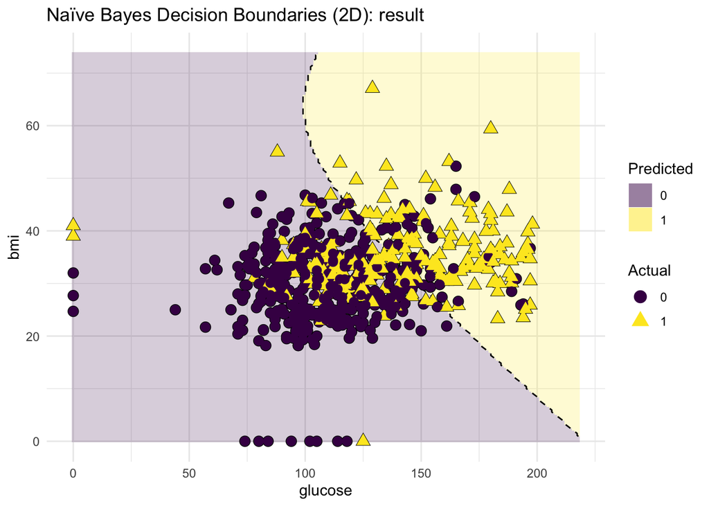

```r
classifier_plot(naive_model, pima_train)
```

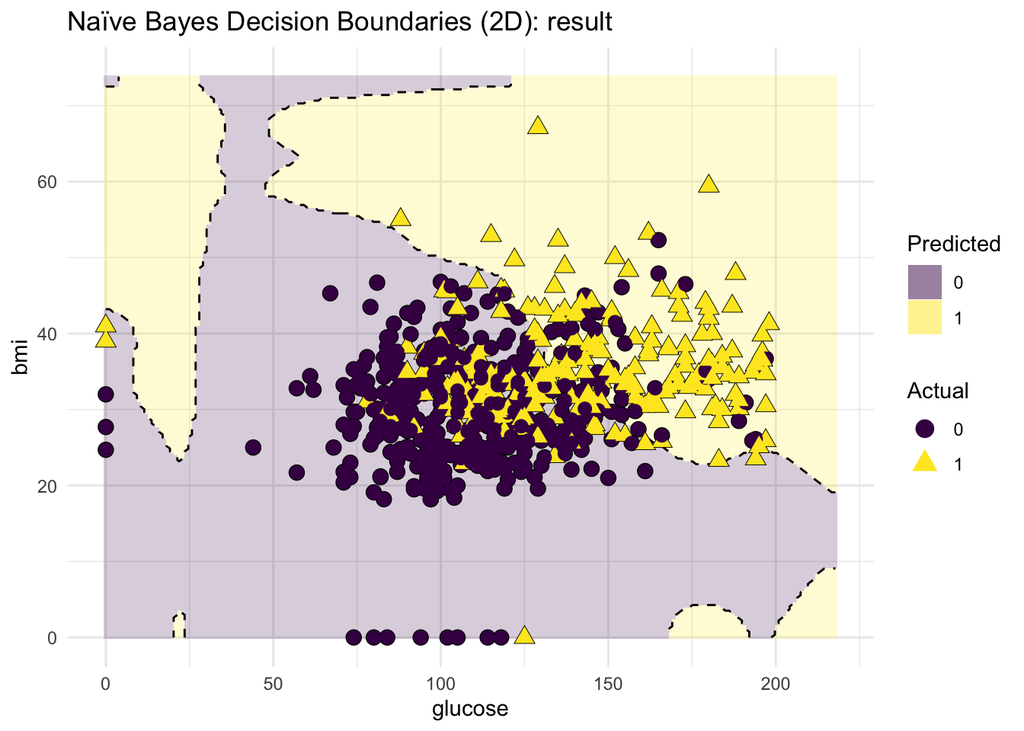

```r
classifier_plot(kernel_bayes, pima_train)
```

```r
# The plot for the initial naive bayes model is all right. There are still plenty of values on the wrong side of the line, but I would say that it has the general idea.
# This model is overfitted quite a bit. It really only has the same accuracy as the first model, but there are random areas of yellow that do not even have the outlier values in them.
```

[output not shown]